# Mandelbrot Set-Single vs Multithreaded v2

## Introduction

- Christian Hollinger created a series of articles comparing Go and Python in different data engineering use cases. In the first article in the series, [A Data Engineering Perspective on Go vs. Python (Part 1)](https://chollinger.com/blog/2020/06/a-data-engineering-perspective-on-go-vs.-python-part-1/), he show showed both single threaded and multi-threaded Python and Go implementations for generating the [Mondelbrot Set](https://en.wikipedia.org/wiki/Mandelbrot_set) and creating the Mandelbrot fractal for the set..
- I would venture to say that many or most of you have heard of fractals before and if you have seen any images of fractals the image of the Mandelbrot Set would probably have been among them. In fact, we will see images of Mandelbrot and Julia fractals this file.
- I have cleaned up, changed and expanded upon the author's code. In the zip file provided, you can find Python code (`mandelbrot.py` , `mandelbrot-array.py` and `mandelbrot_multi.py`) and Go code (`mandelbrot.go` and `mandelbrot_multi.go`) for generating the Mandelbrot fractal. This way you can create your own performance analysis of Python (single and multi-threaded) vs Go (with and without concurrency) similar to the one presented in the article:

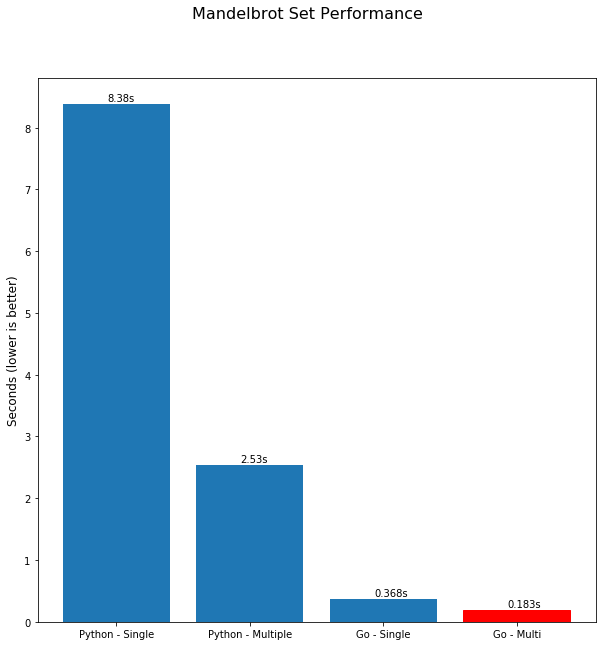

## Requirements

1. Read the descriptions of the Mandelbrot and Julia sets below.
2. Run the single threaded and multi-threadeded Python programs for generating the Mandelbrot fractals at the command line:
   - `python mandelbrot.py`
   - `python mandelbrot-array.py`
   - `python mandelbrot-multi.py`
3. Add a loop to each of the two Go programs (`mandelbrot.go` and `mandelbrot_multi.go`) to generate the Mandelbrot fractals 5 times and display the average execution time in each case. (In Go you can use the time package to find the elapsed time. See https://yourbasic.org/golang/measure-execution-time/.)
4. Run the two Go programs (`mandelbrot.go` and `mandelbrot_multi.go`) at the command line:
   - `go run mandelbrot.go`
   - `go mandelbrot-multi.go`
5. Record the average durations of the runs in a table
6. Make some modifications to each of the two Go programs so that they create a Julia fractal with a fixed complex number $c$ instead. Choose one of the following values for c:
   - $c = -0.4 + 0.6i$
   - $c = -0.8 + 0.156i$
   - $c = -0.7269 + 0.1889i$
7. Generate a performance table (as in requirement 4 above) for your (single and multi-threaded) Julia fractal programs. You don't have to create Python versions of the Julia programs (unless you want to).
8. (Optional). We provided a fast Python single threaded implementation (`mandelbrot-array.py`) that uses NumPy arrays and special NumPy array operations. Can you find/create a similar Go implemenatation (with or without concurrency)? How do their performances compare?

   *Note*: I provide both Go code for saving the fractal images to files. You need to save the image files generated for each of your Go programs for creating Julia fractals. **This is a way of checking that your programs are really generating Julia fractals!**

## Sample Performance Table

| Num. of CPUs | Language | Concurrency? | Avg. Duration |
| --- | --- | --- | --- |
| 1 | Python | No | ? |
| 1 | Go | No | ? |
| 1 | Python | Yes | ? |
| 1 | Go | Yes | ? |
| 2 | Python | Yes | ? |
| 2 | Go | Yes | ? |
| 3 | Python | Yes | ? |
| 3 | Go | Yes | ? |
| 4 | Python | Yes | ? |
| 4 | Go | Yes | ? |

## What are Fractals?

A fractal is "a rough or fragmented geometric shape that can be split into parts, each of which is (at least approximately) a reduced-size copy of the whole," a property called self-similarity.

The term fractal was coined by Benoît Mandelbrot in 1975 and was derived from the Latin fractus meaning "broken" or "fractured." A mathematical fractal is based on an equation that undergoes iteration, a form of feedback based on recursion.

See http://www.marywood.edu/math/fractals.html

## The Mandelbrot Set

The `Mandelbrot set` is the set of complex numbers $c$ for which the sequence $z_0, z_1, z_2,...$ generated by the recurrence equation $z = z^2 + c$, with initial value $z_0 = 0$, remains bounded.

We iterate the equation for each complex number `c` to determine if `c` is in the Mandelbort set or not

Let us look at some examples for different values of $c$.

Suppose we start with the constant $c = 1$. Here are the first few terms of the sequence generated by the recurrence equation $z = z^2 + 1$:

$$z_0 = 0$$$$z_1 = 0^2 + 1 = 1$$$$z_2 = 1^2 + 1 = 2$$$$z_3 = 2^2 + 1 = 5$$$$z_4 = 5^2 + 1 = 26$$$$z_5 = 26^2 + 1 = BIG$$$$z_6 = BIGGER$$$$z_7 = REALLY BIG$$

The terms get larger and larger as the number of terations increases. So the sequence is unbounded and $c=1$ is **not** in the Mandebrot set.

As another example, choose $c = 0$.

$$z_0 = 0$$$$z_1 = 0^2 + 0 = 0$$$$z_2 = 0^2 + 0 = 0$$

...

Clearly, the are terms are zero and the sequence is bounded. So $c=0$ is in the Mandelbrot set.

If we now choose $c = -1$, something else happens.

$$z_0 = 0$$$$z_1 = 0^2 - 1 = -1$$$$z_2 = (-1)^2 - 1 = 0$$

$$z_4 = (-1)^2 - 1 = 0$$

.

We see that the terms bounce back and forth between $0$ and $-1$ and so the sequence is bounded. So $c=-1$ is in the Mandelbrot set.

## Complex Numbers

- Complex numbers are based on the number $i$ which is defined to be the square root of $-1$, so $i*\cdot i=-1$. This number isn't a real number, in other words it does not appear on the usual number line. For this reason it is called an *imaginary number*.
- Now any **complex number** is of the form $a + bi$, where $a$ and $b$ are real numbers. The numbers $1 + 2i$ or $5 - 8i$ are both examples of complex numbers.
- Note that any real numbler $r$ can be written in the form $r+0i$. In this way, we can consider **real numbers** as special **complex numbers**.
- There are rules for performing arithmetic with complex numbers (which extend the rules of arithmetic for the real numbers they contain).
- The **absolute value** of a complex number $c=a+bi$ is $\sqrt{a^2+b^2}$. It represents the distance from $z$ to the original in the complex plane (see below).

## Escape Condition for the Mandelbrot Plotting Algorithm

- If the absolute of $c$ is greater than 2, then $c$ is not in the Mandelbrot Set.
- If the abolute of $c$ is less than or equal to 2 and at some point in our iteration the absolute value of $z_n$ is greater than 2, we know further iterations of the recurrence equation inevitably head towards positive or negative infinity. So, once again, $c$ is not in the Mandelbrot Set.

## The Complex Plane

[figure not shown]

Let's look at an example of the iteration of $z=z^2 + c$ when $c$ is the complex number $c=i$.

$$z_0 = 0$$$$z_1 = 0^2 + i = i$$$$z_2 = i^2 + i = -1 + i$$$$z_3 = (-1+i)^2 + i = -i$$$$z_4 = (-i)^2 + i = -1 + i$$$$z_5 = (-1+i)^2 + i = -i$$$$z_6 = (-i)^2 + i = -1 + i$$

See https://plus.maths.org/content/unveiling-mandelbrot-set for more examples.

```python
# interactive online app for viewing the Mandelbrot Set
from IPython.display import IFrame
display(IFrame("http://xaos-project.github.io/XaoSjs/", 900,500))
```

[interactive chart not shown]

## Julias Sets

- The `Mandelbrot set` is the set of complex numbers $c$, for which the sequence $\{z_n\}$ generated by the recurrence equation $z = z^2 + c$, $z_0 = 0$ remains bounded. Thus we iterate the equation for each `c` to determine if $c$ is in the set.
- A `Julia set`, for a fixed complex number $c$, is the set of complex numbers $z$ for which the sequence $\{z_n\}$ generated by the recurrence equation $z = z^2 + c$, $z_0 = z$, remains bounded. Thus we iterate the equation for each $z$ (but start with $z_0 = z$) to determine if $z$ is in the set.
- The escape condtion for the Julia set plotting algorithm is the same as for the Mandelbrot set.

## Deliverables

Submit a zip file containing the following:

1. A pdf document containing the performance table(s) for the Mandelbrot and Julia sets 2.`mandelbrot.go` (with the testing performance loops added)
2. `mandelbrot-multi.go` (with the testing performance loops added) 4.`julia.go` (with the testing performance loops added)
3. `julia-multi.go` (with the testing performance loops added)
4. The two Julia fractal images (for your chosen complex number $c$) generated by your two Go programs (with and without concurrency).

## My Performance Results

```python
!python ./assignment_files/mandelbrot_single/mandelbrot.py
```

```
Duration: 3.2354s
Figure(1000x1000)
```

```python
!python ./assignment_files/mandelbrot_single/mandelbrot-array.py
```

```
Duration: 0.6002s
Figure(1000x1000)
```

```python
!python ./assignment_files/mandelbrot_multi/mandelbrot-multi.py
```

```
Number of cores: 8
1 core(s): 4.4016s
2 core(s): 2.8981s
3 core(s): 2.4191s
4 core(s): 2.1896s
5 core(s): 2.2258s
6 core(s): 2.4212s
7 core(s): 2.4151s
8 core(s): 2.4661s
Figure(1000x1000)
```

```python
!go run ./assignment_files/mandelbrot_single/mandelbrot.go
```

```
Duration: 158.806ms
```

```python
!go run ./assignment_files/mandelbrot_multi/mandelbrot-multi.go
```

```
Number of cores: 8
1 CPUs: 178.87ms
2 CPUs: 108.361ms
3 CPUs: 105.378ms
4 CPUs: 89.389ms
5 CPUs: 104.196ms
6 CPUs: 120.72ms
7 CPUs: 117.066ms
8 CPUs: 127.627ms
```

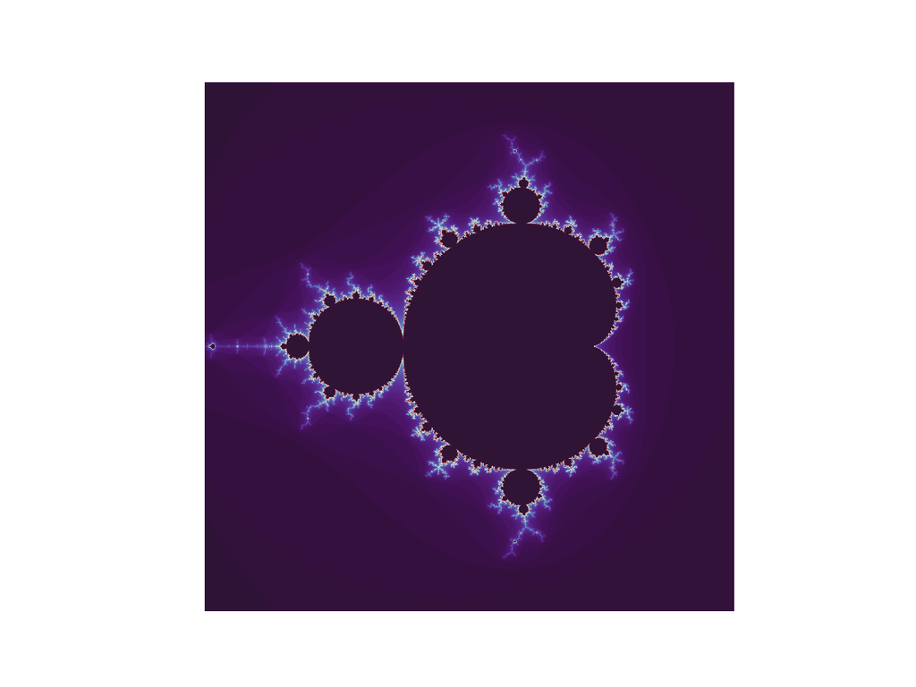

## Plot of the Julia Set

- With the complex number $c = -0.8 + 0.156i$.

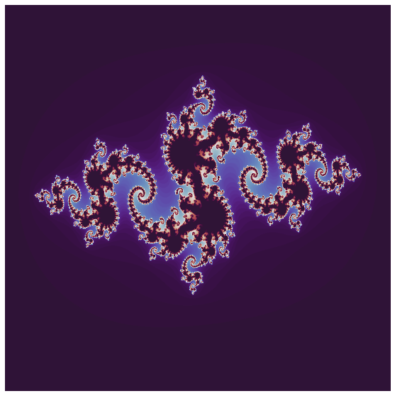

## Plot of the Julia Set

- With the complex number $c = -0.4 + 0.6i$.

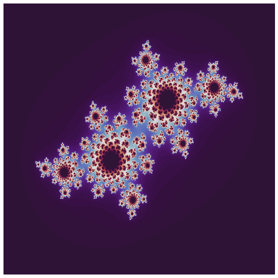